# Mathematical Foundations of Data Science Assignment 1

#### Trimester 1, 2023

**1. Consider the function g whose graph is below**

[figure not shown]

(a) What is the domain of g?  
*Answer:*  
The domain of g is $\{x\in R\ |\ 3 \leqq x < 3 ,\ 3 < x \leqq 5 \}$.  
(b) What is the range of g?  
*Answer:*  
The domain of g is $\{y\in R\ |\ 0 < x \leqq 4 \}$.  
(c) Is g a one-to-one function? Explain your answer.  
*Answer:*  
No, because when $y \in [1,2]$, it conresponds to two $x$ values.

2. In total, how much money do the people in Adelaide spend buying cups of coffee every year?  
Note that you are not expected to get an exact answer! This is an exercise in $estimation$ - there is no one correct number that will get you full marks. Rather, you must give a reasonable argument with plausible estimates following the principles presented in the course materials. You need to justify your assumptions and make it clear how you arrived at your answer.

3. Let $J = \{ x ∈ N | −7 ≤ 3x − 4 < 9 \}$ , $K = (0, 3]$, and $L = \{ 0,1 /2, 3 \}$ .

4. You should complete this question using a Jupyter Notebook. All of the code you will need to complete this question can be taken directly or generalised from the week 1 computer exercise, or will be given to you in the question.

Download the file movie data.csv from MyUni (this file comes from the imdb-5000-movie-dataset on Kaggle). Then use Python to do the following:  
(a) Using pandas, read the data into a dataframe and print out its tail().

```python
import pandas as pd

df = pd.read_csv("movie_metadata.csv")
df.tail()
```

|  | color | director_name | num_critic_for_reviews | duration | director_facebook_likes | actor_3_facebook_likes | actor_2_name | actor_1_facebook_likes | gross | genres | ... | num_user_for_reviews | language | country | content_rating | budget | title_year | actor_2_facebook_likes | imdb_score | aspect_ratio | movie_facebook_likes |
| --- | --- | --- | --- | --- | --- | --- | --- | --- | --- | --- | --- | --- | --- | --- | --- | --- | --- | --- | --- | --- | --- |
| 5038 | Color | Scott Smith | 1.0 | 87.0 | 2.0 | 318.0 | Daphne Zuniga | 637.0 | NaN | Comedy\|Drama | ... | 6.0 | English | Canada | NaN | NaN | 2013.0 | 470.0 | 7.7 | NaN | 84 |
| 5039 | Color | NaN | 43.0 | 43.0 | NaN | 319.0 | Valorie Curry | 841.0 | NaN | Crime\|Drama\|Mystery\|Thriller | ... | 359.0 | English | USA | TV-14 | NaN | NaN | 593.0 | 7.5 | 16.00 | 32000 |
| 5040 | Color | Benjamin Roberds | 13.0 | 76.0 | 0.0 | 0.0 | Maxwell Moody | 0.0 | NaN | Drama\|Horror\|Thriller | ... | 3.0 | English | USA | NaN | 1400.0 | 2013.0 | 0.0 | 6.3 | NaN | 16 |
| 5041 | Color | Daniel Hsia | 14.0 | 100.0 | 0.0 | 489.0 | Daniel Henney | 946.0 | 10443.0 | Comedy\|Drama\|Romance | ... | 9.0 | English | USA | PG-13 | NaN | 2012.0 | 719.0 | 6.3 | 2.35 | 660 |
| 5042 | Color | Jon Gunn | 43.0 | 90.0 | 16.0 | 16.0 | Brian Herzlinger | 86.0 | 85222.0 | Documentary | ... | 84.0 | English | USA | PG | 1100.0 | 2004.0 | 23.0 | 6.6 | 1.85 | 456 |

5 rows × 28 columns

(b) Create a histogram of duration for all movies.  
*Hint: Remember to add axis labels.*

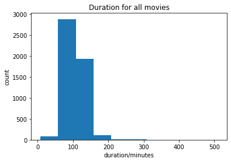

```python
import matplotlib.pyplot as plt

plt.hist(df.duration)
plt.xlabel("duration/minutes")
plt.ylabel("count")
plt.title("Duration for all movies")
plt.show()
```

(c) Calculate the mean duration of all movies. Print out a statement showing the mean duration.  
*Hint: In the week 1 computer exercise, we saw how to print out a line containing text and numbers.*

```python
mean_duration = df.duration.mean()
print("the mean duration of all movies is {:.1f} minutes".format(mean_duration))
```

```
the mean duration of all movies is 107.2 minutes
```

(d) Among movies longer than 180 minutes, find the movie with the highest gross.  
*Hint: Try creating a new dataframe that only contains movies with duration greater than 180.*

```python
df2 = df[df.duration > 180]
df_gross_max = df2[df2.gross == df2.gross.max()]
df_gross_max
```

|  | color | director_name | num_critic_for_reviews | duration | director_facebook_likes | actor_3_facebook_likes | actor_2_name | actor_1_facebook_likes | gross | genres | ... | num_user_for_reviews | language | country | content_rating | budget | title_year | actor_2_facebook_likes | imdb_score | aspect_ratio | movie_facebook_likes |
| --- | --- | --- | --- | --- | --- | --- | --- | --- | --- | --- | --- | --- | --- | --- | --- | --- | --- | --- | --- | --- | --- |
| 26 | Color | James Cameron | 315.0 | 194.0 | 0.0 | 794.0 | Kate Winslet | 29000.0 | 658672302.0 | Drama\|Romance | ... | 2528.0 | English | USA | PG-13 | 200000000.0 | 1997.0 | 14000.0 | 7.7 | 2.35 | 26000 |

1 rows × 28 columns

```python
print("The movie longer than 180 minutes with the highest gross {} is \"{}\""
      .format(df_gross_max.gross[26],df_gross_max.movie_title[26]))
```

```
The movie longer than 180 minutes with the highest gross 658672302.0 is "Titanic "
```

(e) Find the Western movie with the highest gross among movies longer than 180 minutes.  
*Hint: Many movies have multiple genres. We want to include all movies with Western in the genre, not just movies where Western is the only genre. The string method .str.contains() might be useful here.*

```python
df3 = df2[df2.genres.str.contains("Western")]
df3_gross_max = df3[df3.gross == df3.gross.max()]
df3_gross_max
```

|  | color | director_name | num_critic_for_reviews | duration | director_facebook_likes | actor_3_facebook_likes | actor_2_name | actor_1_facebook_likes | gross | genres | ... | num_user_for_reviews | language | country | content_rating | budget | title_year | actor_2_facebook_likes | imdb_score | aspect_ratio | movie_facebook_likes |
| --- | --- | --- | --- | --- | --- | --- | --- | --- | --- | --- | --- | --- | --- | --- | --- | --- | --- | --- | --- | --- | --- |
| 2356 | Color | Kevin Costner | 92.0 | 236.0 | 0.0 | 232.0 | Michael Spears | 933.0 | 184208848.0 | Adventure\|Drama\|Western | ... | 382.0 | English | USA | PG-13 | 22000000.0 | 1990.0 | 839.0 | 8.0 | 2.35 | 0 |

1 rows × 28 columns

```python
print("The western movie longer than 180 minutes with the highest gross {} is \"{}\""
      .format(df3_gross_max.gross[2356],df3_gross_max.movie_title[2356]))
```

```
The western movie longer than 180 minutes with the highest gross 184208848.0 is "Dances with Wolves "
```

Present your answers as a full Jupyter Notebook. Your notebook must include code to find the results, and text answering the questions based on the output of your code. Download this notebook and convert to a PDF and submit with your assignment.